# Final Report - Group 01

##### Option 1: Log Transform

To address the severe right skew in the 2022 broadband subscription values, we applied a log transformation. First, all countries with a broadband value of zero were removed, as the logarithm of zero is undefined. We then created a new column, log_broadband, by taking the natural log of the broadband subscription values in the data set.

After the transformation, we visualized the distribution of log_broadband using a histogram and Quantile - Quantile (Q-Q) plot to assess whether the skewness had improved. However, the histogram and Q-Q plot indicate that the log transformation did not adequately normalize the data.

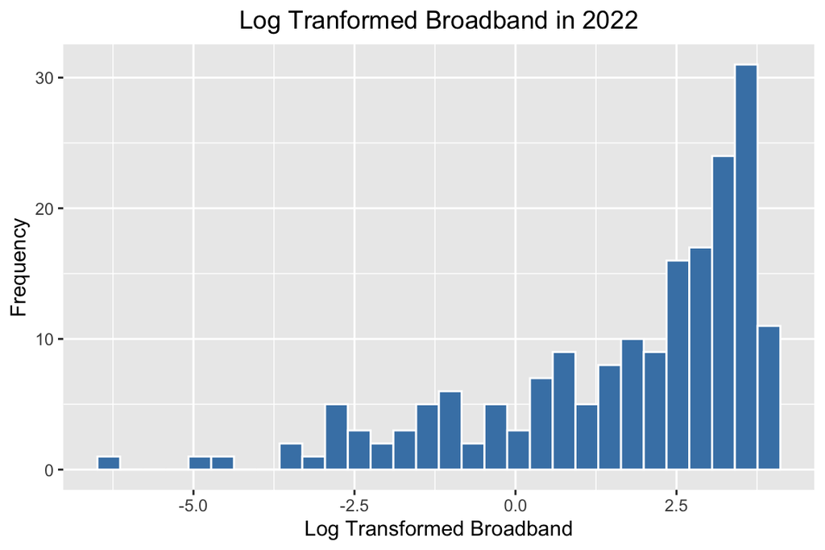

```
##
##  Shapiro-Wilk normality test
##
## data:  data_2022$log_broadband
## W = 0.85633, p-value = 2.711e-12
```

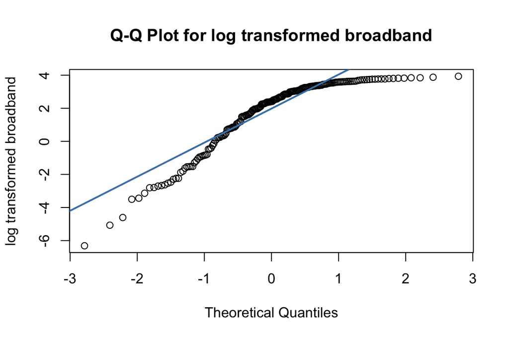

The histogram shows that the log-transformed broadband values in 2022 is left-skewed. Furthermore, the S-shaped curve on the Q-Q plot provides further evidence that the log transformed data do not appear to have a normal distribution.